*Initializing libraries*

```r
library(ggplot2)
library(dplyr)
library(lubridate)
library(MASS)
```

*Defining methods for the tasks in the project*

```r
# Define a function to load and prepare data
load_data <- function(file_path) {
  data <- read.csv(file_path)
  data$date <- as.Date(data$date)
  data$logcases <- log10(data$cases)
  data$logdeaths <- log10(data$deaths)
  return(data)
}

# Define a function to create boxplots comparing years
create_boxplot <- function(data1, data2, title, y_label) {
  boxplot(data1[data1 != -Inf], data2[data2 != -Inf],
          outline = FALSE,
          names = c("2020", "2021"),
          main = title,
          ylab = y_label)
}

# Function to summarize cases by month
summarize_by_day <- function(data, column) {
  data %>%
    mutate(month = floor_date(date, "day")) %>%
    group_by(month) %>%
    summarise(total = sum({{column}}, na.rm = TRUE))
}

# Function to create a bar plot for monthly totals
plot_daily_totals <- function(summary_data, title, y_label, fill_color) {
  ggplot(summary_data, aes(x = month, y = total)) +
    geom_col(fill = fill_color) +
    labs(title = title, x = "Month", y = y_label) +
    theme_minimal() +
    scale_x_date(date_labels = "%B", date_breaks = "1 month")
}

# Define a function to filter data within the IQR range
filter_iqr <- function(x) {
  Q1 <- quantile(x, 0.25, na.rm = TRUE)  # 1st quartile
  Q3 <- quantile(x, 0.75, na.rm = TRUE)  # 3rd quartile
  IQR_value <- IQR(x, na.rm = TRUE)      # Interquartile range
  filtered <- x[x >= (Q1 - 1.5 * IQR_value) & x <= (Q3 + 1.5 * IQR_value)]
  return(filtered)
}
# Function to plot histogram with density overlay
plot_hist_density <- function(data, title, binwidth, x_label = "Values") {
  ggplot(data.frame(data), aes(x = data)) +
    geom_histogram(aes(y = ..density..), binwidth = binwidth, color = "black", fill = "lightblue") +
    geom_density(color = "red", linewidth = 1) +
    ggtitle(title) +
    xlab(x_label) +
    theme_minimal()
}

# Function to fit and plot gamma distribution
plot_gamma_fit <- function(data, title, binwidth, x_label = "Values") {
  fit_gamma <- fitdistr(data, "gamma")
  shape_gamma <- fit_gamma$estimate[1]
  rate_gamma <- fit_gamma$estimate[2]

  ggplot(data.frame(data), aes(x = data)) +
    geom_histogram(aes(y = ..density..), binwidth = binwidth, color = "black", fill = "lightblue") +
    stat_function(fun = dgamma, args = list(shape = shape_gamma, rate = rate_gamma), color = "red", size = 1) +
    ggtitle(title) +
    xlab(x_label) +
    ylab("Density") +
    theme_minimal()
}

# Function to plot ECDF
plot_ecdf <- function(data, title, x_label = "Values") {
  ggplot(data.frame(data), aes(x = data)) +
    stat_ecdf(geom = "step", color = "blue") +
    ggtitle(title) +
    xlab(x_label) +
    ylab("ECDF") +
    theme_minimal()
}

# Function to create Q-Q plots against Gamma distribution
plot_qq_gamma <- function(data, title) {
  fit_gamma <- fitdistr(data, "gamma")
  shape <- fit_gamma$estimate[1]
  rate <- fit_gamma$estimate[2]
  n <- length(data)
  theoretical_quantiles <- qgamma(ppoints(n), shape = shape, rate = rate)
  qq_data <- data.frame(Observed = sort(data), Theoretical = theoretical_quantiles)

  ggplot(qq_data, aes(x = Theoretical, y = Observed)) +
    geom_point() +
    geom_abline(slope = 1, intercept = 0, color = "red", linetype = "dashed") +
    ggtitle(title) +
    xlab("Theoretical Quantiles (Gamma)") +
    ylab("Observed Quantiles") +
    theme_minimal()
}

# Define a function to filter data by state
filter_by_state <- function(data, states) {
  filtered_data <- subset(data, state %in% states)
  return(filtered_data)
}
```

*Attach Data File*

```r
Covid2020 <- load_data('us-counties-2020.csv')
Covid2021 <- load_data('us-counties-2021.csv')
```

# Question 1

## 1a:Create boxplots for the “Cases” and “Deaths” variables comparing the variables between the 2 datasets, i.e. two figures (one for each variable) with 2 boxplots (for the 2 different datasets) in each. Describe and run summary statistics on the two chosen variables and explain them in your words. min. 2-3 sentences (2%)

*The data is very large and contains many outliers. Hence taking log of the data to do a box plot, so that maximum amount of data can be captured. Also plotting the box plot without the outliers to display a smooth graph. Few of the higher values are hence not captured*

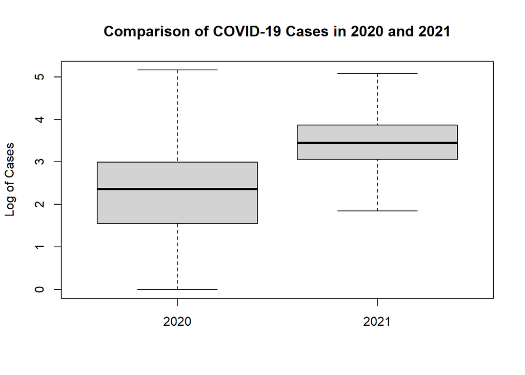

```r
# Create boxplots comparing 2020 and 2021 for cases and deaths
create_boxplot(Covid2020$logcases, Covid2021$logcases, "Comparison of COVID-19 Cases in 2020 and 2021", "Log of Cases")
```

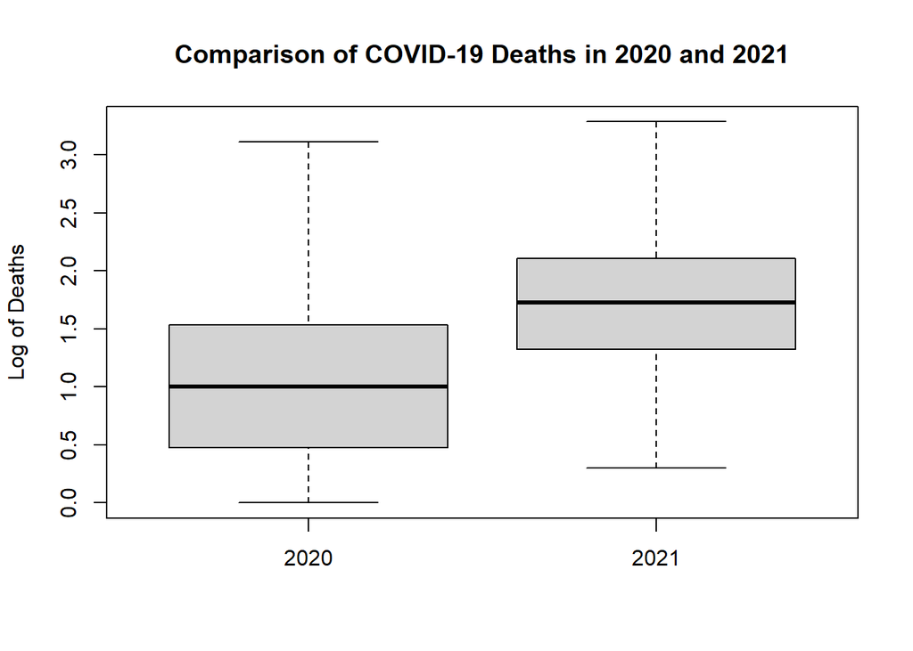

```r
create_boxplot(Covid2020$logdeaths, Covid2021$logdeaths, "Comparison of COVID-19 Deaths in 2020 and 2021", "Log of Deaths")
```

*Capturing the summary of all original data along with the log data to understand the above box plot better*

```r
# Summary statistics for Cases
print("Summary 2020 cases")
```

```
## [1] "Summary 2020 cases"
```

```r
summary(Covid2020$cases)
```

```
##    Min. 1st Qu.  Median    Mean 3rd Qu.    Max.
##       0      36     228    1952     993  770915
```

```r
summary(Covid2020$logcases[Covid2020$logcases!=-Inf])
```

```
##    Min. 1st Qu.  Median    Mean 3rd Qu.    Max.
##   0.000   1.556   2.358   2.267   2.997   5.887
```

```r
print("Summary 2021 cases")
```

```
## [1] "Summary 2021 cases"
```

```r
summary(Covid2021$cases)
```

```
##    Min. 1st Qu.  Median    Mean 3rd Qu.    Max.
##       0    1136    2778   11160    7340 1697286
```

```r
summary(Covid2021$logcases[Covid2021$logcases!=-Inf])
```

```
##    Min. 1st Qu.  Median    Mean 3rd Qu.    Max.
##   0.000   3.057   3.445   3.471   3.866   6.230
```

```r
# Summary statistics for Deaths
print("Summary 2020 Deaths")
```

```
## [1] "Summary 2020 Deaths"
```

```r
summary(Covid2020$deaths)
```

```
##    Min. 1st Qu.  Median    Mean 3rd Qu.    Max.    NA's
##     0.0     0.0     4.0    53.6    21.0 25144.0   18761
```

```r
summary(Covid2020$logdeaths[Covid2020$logdeaths!=-Inf])
```

```
##    Min. 1st Qu.  Median    Mean 3rd Qu.    Max.    NA's
##   0.000   0.477   1.000   1.048   1.531   4.400   18761
```

```r
print("Summary 2021 Deaths")
```

```
## [1] "Summary 2021 Deaths"
```

```r
summary(Covid2021$deaths)
```

```
##    Min. 1st Qu.  Median    Mean 3rd Qu.    Max.    NA's
##     0.0    20.0    52.0   193.6   125.0 35382.0   28470
```

```r
summary(Covid2021$logdeaths[Covid2021$logdeaths!=-Inf])
```

```
##    Min. 1st Qu.  Median    Mean 3rd Qu.    Max.    NA's
##   0.000   1.322   1.724   1.731   2.107   4.549   28470
```

*The range of this dataset is very big. The minimum and maximum value of the number of cases in 2020 are 0 and 770915 with a mean value of 1952. The minimum and maximum value of the number of deaths in 2020 are 0 and 25144 with a mean value of 53.6.The minimum and maximum value of the number of cases in 2021 are 0 and 1697286 with a mean value of 11160.The minimum and maximum value of the number of deaths in 2021 are 0 and 35382 with a mean value of 193.6.*

*Plotting the number of covid cases and deaths for both 2020 and 2021 in each month to understand the data*

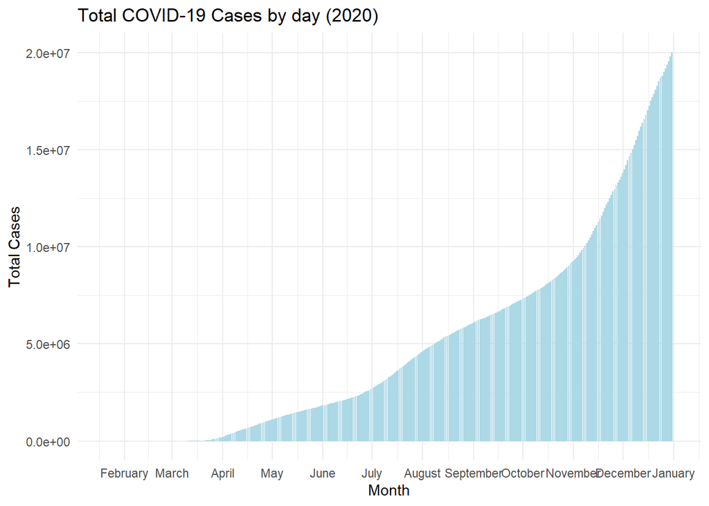

```r
Covid2020$date <- as.Date(Covid2020$date)
Covid2021$date <- as.Date(Covid2021$date)

# Summarize Cases for 2020 and 2021
cases_by_day_2020 <- summarize_by_day(Covid2020, cases)
cases_by_day_2021 <- summarize_by_day(Covid2021, cases)

# Plot total cases by day for 2020 and 2021
plot_daily_totals(cases_by_day_2020, "Total COVID-19 Cases by day (2020)", "Total Cases", "lightblue")
```

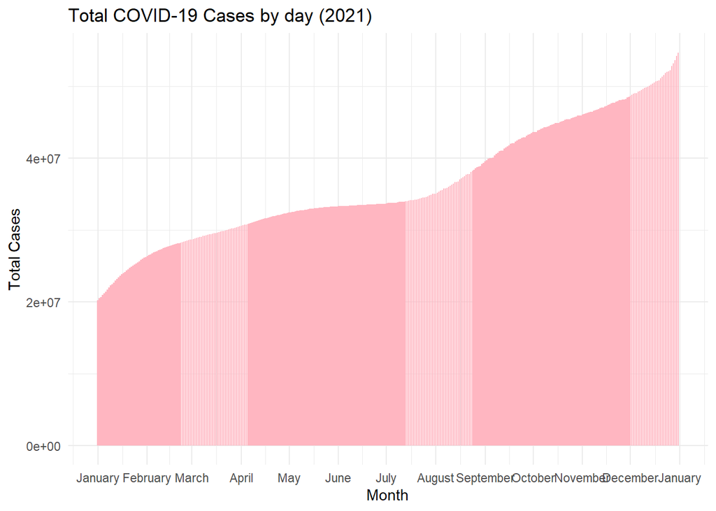

```r
plot_daily_totals(cases_by_day_2021, "Total COVID-19 Cases by day (2021)", "Total Cases", "lightpink")
```

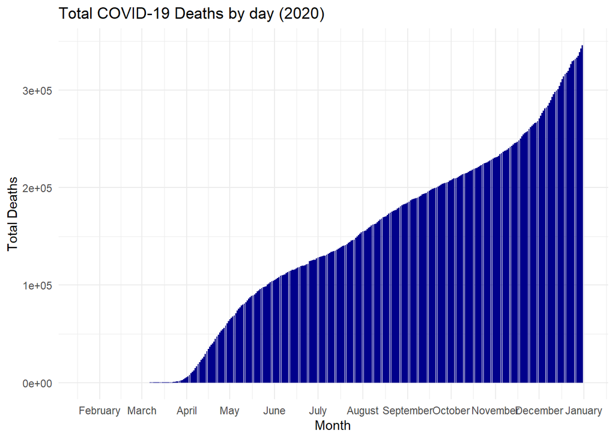

```r
# Summarize deaths for 2020 and 2021
deaths_by_day_2020 <- summarize_by_day(Covid2020, deaths)
deaths_by_day_2021 <- summarize_by_day(Covid2021, deaths)

# Plot total deaths by day for 2020 and 2021
plot_daily_totals(deaths_by_day_2020, "Total COVID-19 Deaths by day (2020)", "Total Deaths", "darkblue")
```

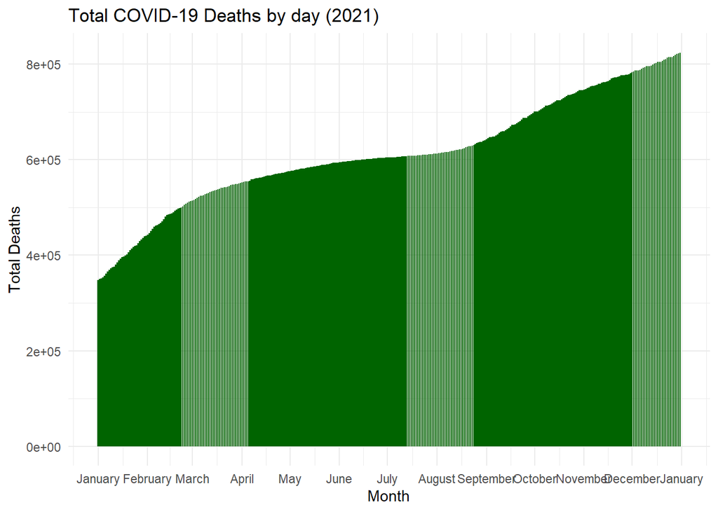

```r
plot_daily_totals(deaths_by_day_2021, "Total COVID-19 Deaths by day (2021)", "Total Deaths", "darkgreen")
```

*The above graphs explains that the no of cases and deaths in both the datasets for 2020 and 2021 are stored in cumulative format.*

## 1b:Create histograms for those two variables in the 2 datasets (you choose the histogram bin width). Describe the distributions in terms of known parametric distributions and similarities/ differences among them. Plot the distribution you think matches the histogram (e.g. normal, chis-square, gamma, t-distribution, etc.) overlayed on the histogram. min. 2-3 sentences

*Analyzing 2020 data*

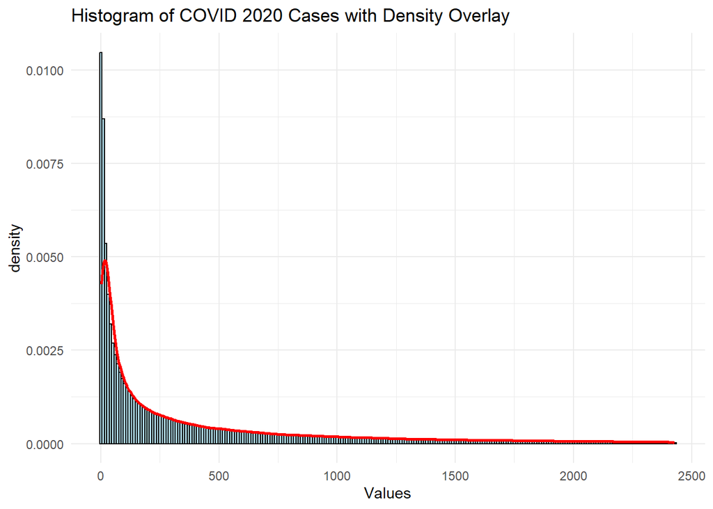

```r
# Filtering IQR for both cases and deaths for 2020
cases_iqr_2020 <- filter_iqr(Covid2020$cases)
deaths_iqr_2020 <- filter_iqr(Covid2020$deaths)

# Remove non-positive values to capture a better graph
cases_iqr_2020 <- cases_iqr_2020[cases_iqr_2020 > 0 & !is.na(cases_iqr_2020) & is.finite(cases_iqr_2020)]
deaths_iqr_2020 <- deaths_iqr_2020[deaths_iqr_2020 > 0 & !is.na(deaths_iqr_2020) & is.finite(deaths_iqr_2020)]

# Plot histogram and density for cases and deaths in 2020
plot_hist_density(cases_iqr_2020, "Histogram of COVID 2020 Cases with Density Overlay", binwidth = 10)
```

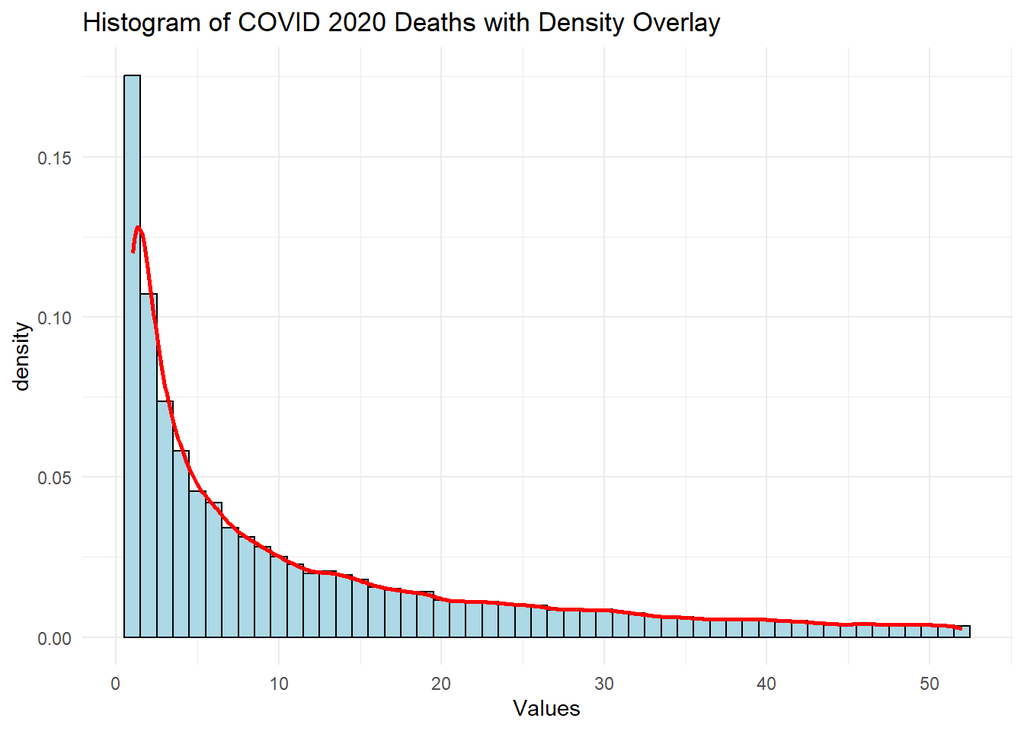

```r
plot_hist_density(deaths_iqr_2020, "Histogram of COVID 2020 Deaths with Density Overlay", binwidth = 1)
```

*Since the data in both the above histograms are continuous, positive and have skewed distribution. I think Gamma distribution would be the best fit for both the graphs.*

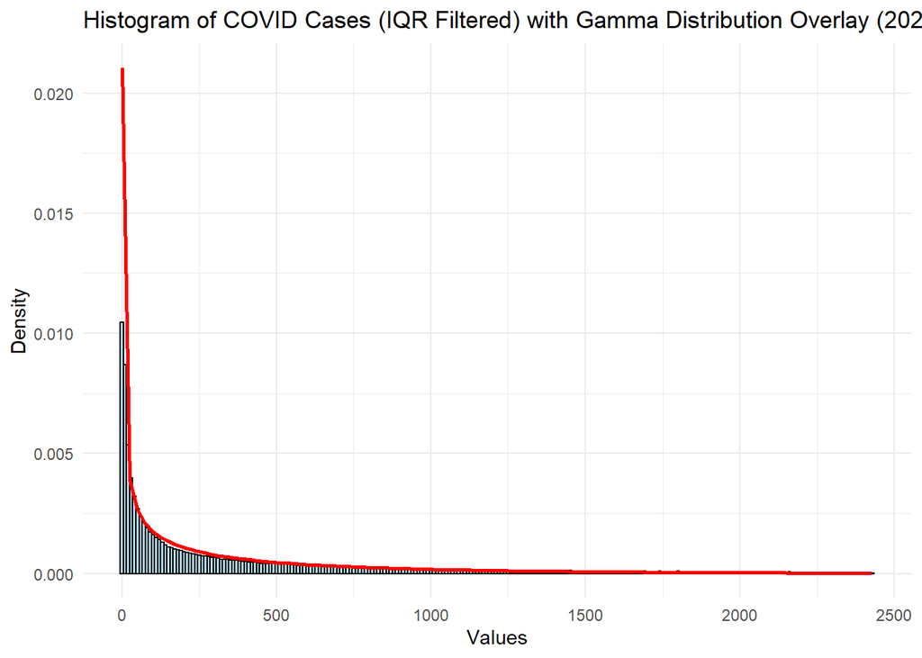

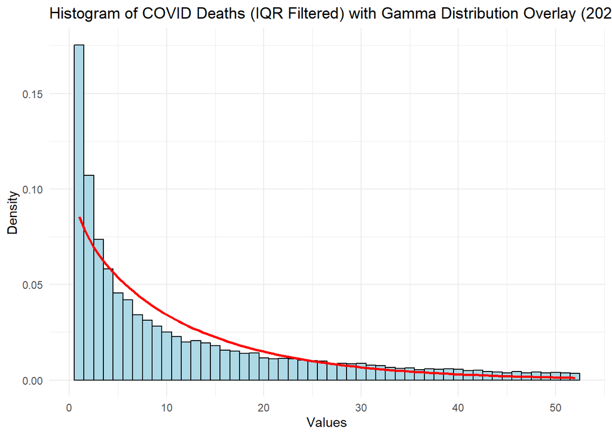

```r
suppressWarnings({
print(plot_gamma_fit(cases_iqr_2020, "Histogram of COVID Cases (IQR Filtered) with Gamma Distribution Overlay (2020)", binwidth = 10))

print(plot_gamma_fit(deaths_iqr_2020, "Histogram of COVID Deaths (IQR Filtered) with Gamma Distribution Overlay (2020)", binwidth = 1))
})
```

*Analyzing 2021 data*

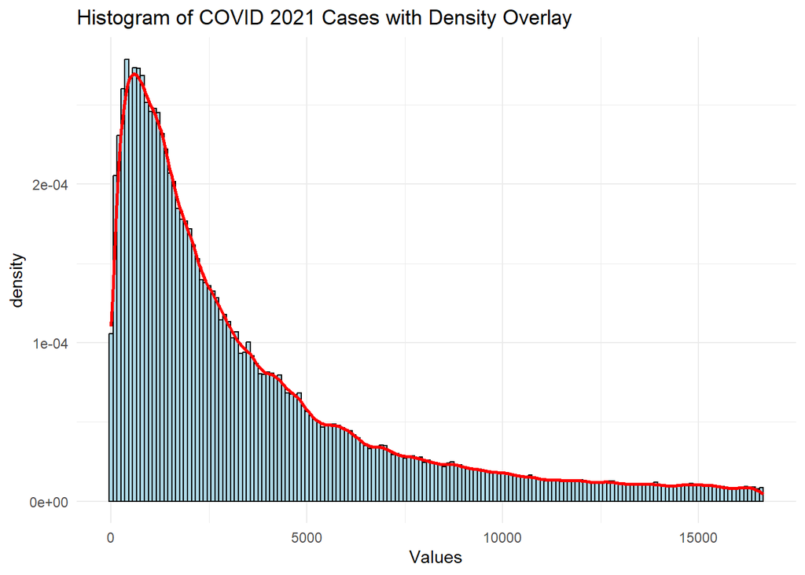

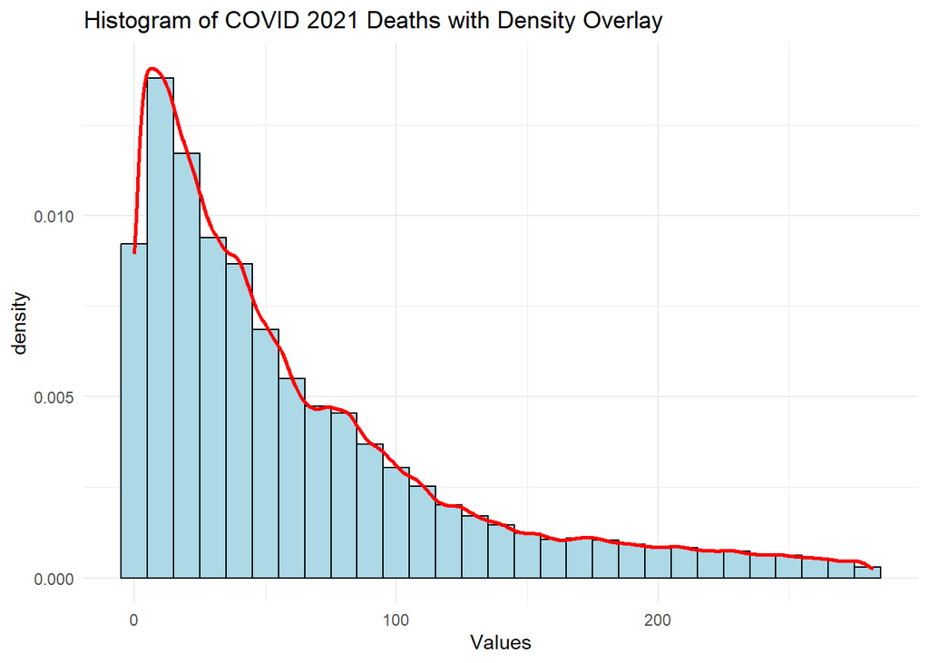

```r
# Repeat for 2021
cases_iqr_2021 <- filter_iqr(Covid2021$cases)
deaths_iqr_2021 <- filter_iqr(Covid2021$deaths)

# Plot histogram and density for cases and deaths in 2021
suppressWarnings({
print(plot_hist_density(cases_iqr_2021, "Histogram of COVID 2021 Cases with Density Overlay", binwidth = 100))
print(plot_hist_density(deaths_iqr_2021, "Histogram of COVID 2021 Deaths with Density Overlay", binwidth = 10))
})
```

*Similar to the 2020 data since the data in both the above histograms are continuous, positive and have skewed distribution. I think Gamma distribution would be the best fit for both the graphs. Since the range of covid cases are very large the gamma fitting cannot be done in the plot.*

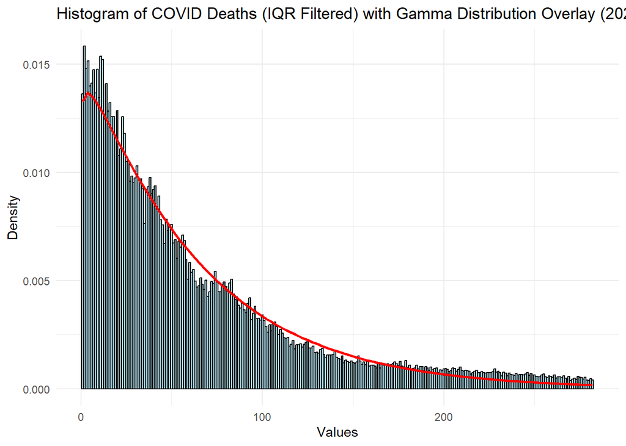

```r
# Remove non-positive values and fit gamma distribution for 2021 cases and deaths
cases_iqr_2021 <- cases_iqr_2021[cases_iqr_2021 > 0 & !is.na(cases_iqr_2021) & is.finite(cases_iqr_2021)]
deaths_iqr_2021 <- deaths_iqr_2021[deaths_iqr_2021 > 0 & !is.na(deaths_iqr_2021) & is.finite(deaths_iqr_2021)]
suppressWarnings({
#plot_gamma_fit(cases_iqr_2021, "Histogram of COVID Cases (IQR Filtered) with Gamma Distribution Overlay (2021)", binwidth = 100)
print(plot_gamma_fit(deaths_iqr_2021, "Histogram of COVID Deaths (IQR Filtered) with Gamma Distribution Overlay (2021)", binwidth = 1))
})
```

## 1c: Plot the ECDFs (Empirical Cumulative Distribution Function) for the two variables in both datasets. Plot the quantile-quantile distribution using a suitable parametric distribution you chose in 1b. Describe features of these plots. min. 2-3 sentences

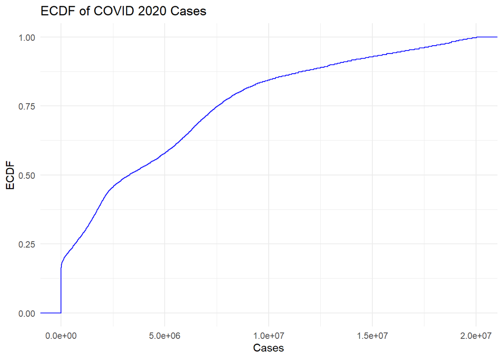

```r
# Plot ECDF for 2020 Cases and Deaths

plot_ecdf(cases_by_day_2020$total, "ECDF of COVID 2020 Cases", "Cases")
```

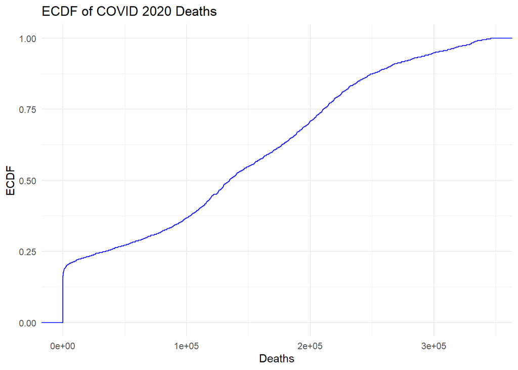

```r
plot_ecdf(deaths_by_day_2020$total, "ECDF of COVID 2020 Deaths", "Deaths")
```

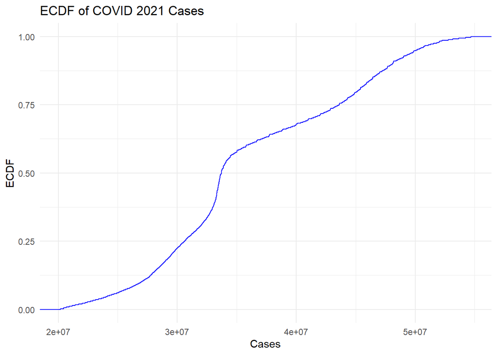

```r
# Plot ECDF for 2021 Cases and Deaths
plot_ecdf(cases_by_day_2021$total, "ECDF of COVID 2021 Cases", "Cases")
```

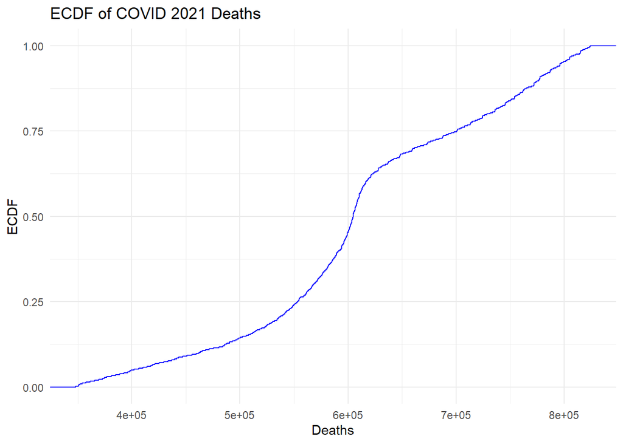

```r
plot_ecdf(deaths_by_day_2021$total, "ECDF of COVID 2021 Deaths", "Deaths")
```

*From the ECDF graph it is evident that in 2020 the total covid-19 cases was initially increasing slowly with a P-50 of around 3m. Later from the second half of 2020 to 2021 the number of covid cases increased faster. The 2021 graph has a comparatively gradual increase.* *There were very few deaths in the first quarter of the year. But later through the remaining of 2020 and 2021, the number of deaths gradually increased at a much faster rate. And, in the second half of 2021 the increase in death rate was much slower.*

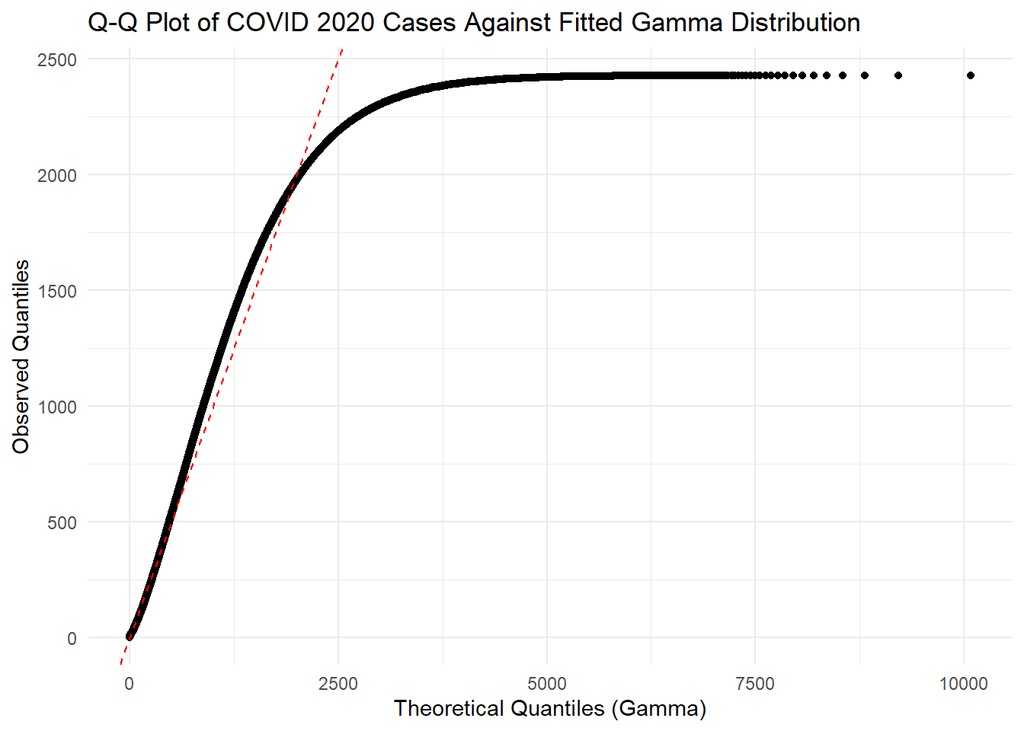

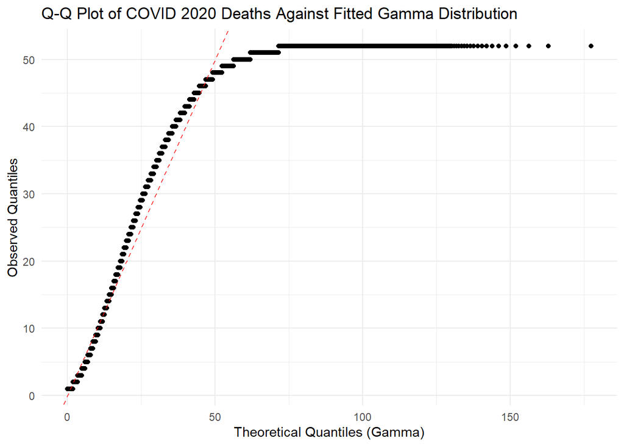

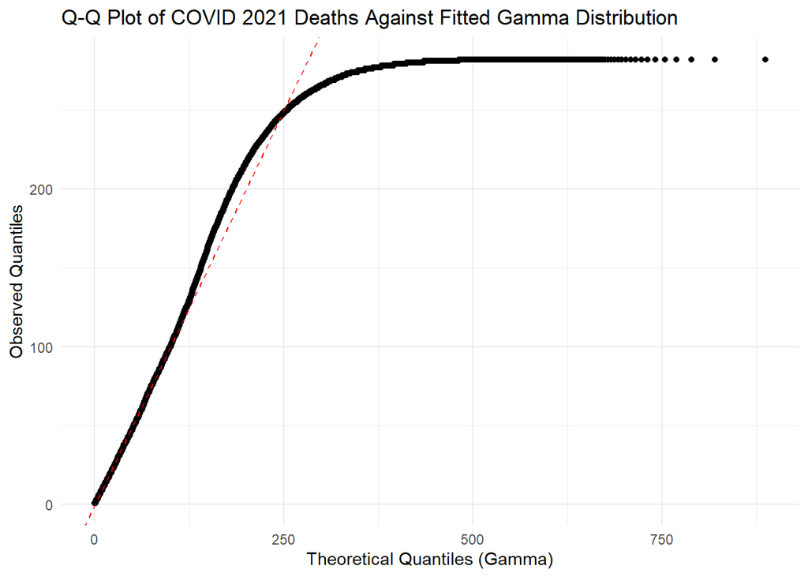

```r
suppressWarnings({
# Q-Q Plot against Gamma distribution for 2020 Cases and Deaths
print(plot_qq_gamma(cases_iqr_2020, "Q-Q Plot of COVID 2020 Cases Against Fitted Gamma Distribution"))
print(plot_qq_gamma(deaths_iqr_2020, "Q-Q Plot of COVID 2020 Deaths Against Fitted Gamma Distribution"))

# Q-Q Plot against Gamma distribution for 2021 Cases and Deaths
#print(plot_qq_gamma(cases_iqr_2021, "Q-Q Plot of COVID 2021 Cases Against Fitted Gamma Distribution"))
print(plot_qq_gamma(deaths_iqr_2021, "Q-Q Plot of COVID 2021 Deaths Against Fitted Gamma Distribution"))
})
```

*The above graphs explain that till a certain value in all the graphs both the theoretical(values generated from the model) and observed value are same. But later there is a sudden increase in the theoritical value, and a large change is observed.*